# The following content is about Bayesian Poisson Regression.

## L Wang

### Bayesian Poisson Distribution background :

1. **Prior probability**

Suppose we have no prior information or knowledge about the value of $\lambda$, we can assume it is an umbiased uniform distribution.

we define the prior distribution of $\boldsymbol{\lambda}$ is

p$(\lambda|H)$ = Uniform(a,b), where a,b are lower and upper limit values of $\lambda$.

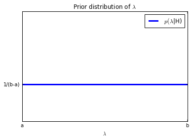

```python
%matplotlib inline
import matplotlib.pyplot as plt
fig, axes = plt.subplots()
plt.setp(axes,xticks = [0.,6.], xticklabels = ["a","b"], yticks = [1,3], yticklabels=["1/(b-a)",""])
plt.axhline(y=1,color = "b" ,linewidth = 3, label ="$p(\lambda$|H)" )
plt.legend(loc="best")
plt.xlabel("$\lambda$")
plt.title("Prior distribution of $\lambda$")
```

2. **Likelihood function**

With the likelihood function the **conditional probability p$(r|\lambda,H)$** , it is a function of both $\boldsymbol{r}$ and $\boldsymbol{\lambda}$ . For fixed value of $\boldsymbol{\lambda}$, p$(r|\lambda,H)$ describes the distribution of $\boldsymbol{r}$ , while for fixed data **r**, p$(r|\lambda,H)$ defines the lilkelihood of $\lambda$, it doesn't have to be normalized.

An interesting property of Poission distribution is both the expectation value and the variance of **r** are $\boldsymbol{\lambda}$, denoted as E(**r**) = Var(**r**) = $\boldsymbol{ \lambda}$.

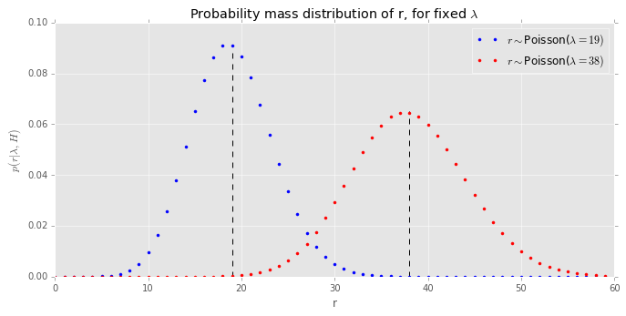

```python
%matplotlib inline
import scipy.stats as stats
import numpy as np
plt.figure(figsize=(11,5))
plt.setp(axes,xticks = [15], xticklabels = ["$\lambda$"])
x = range(60)
y = stats.poisson.pmf(x,19)
y2 =stats.poisson.pmf(x,38)

plt.plot(y,"b.",label= "$r \sim $Poisson($\lambda=19)$")
plt.plot(y2,"r.",label= "$r \sim $Poisson($\lambda=38)$")
plt.vlines(19, 0, 0.09, color = "black", linestyles="--", lw=1)
plt.vlines(38,0,0.065, color = "black",linestyle="--",lw=1)
plt.xlabel("r")
plt.ylabel(r"$p(r|\lambda,H)$")
plt.title("Probability mass distribution of r, for fixed $\lambda$")
plt.legend(loc="best")
plt.style.use("ggplot")
```

3.**Posterior probability**

By employing the Bayes' rule:

## $p(\lambda|r,H)=\frac{p(\lambda|H) p(r|\lambda,H)}{p(r|H)}$

where the denominator $p(r|H)$, also called the evidence, is caculated by integral all the possible values of $\lambda$.

$p(r|H) = \int p(r,\lambda|H) d\lambda = \int p(\lambda|H) p(r|\lambda,H) $

Since the prior $p(\lambda|H) $ is uniform distributed, we obtain the **posterior distribution** of $\lambda$ ,

p$(\lambda|r,H)= p(r|\lambda) = \frac{e ^{-\lambda} \lambda ^{r}}{r!}$.

Though it has the same funtion form of the likelihood function p$(r|\lambda,H)$, unlike $\boldsymbol{r}$ , which can only be **positive integers**, $\boldsymbol{\lambda}$ has **positive continuous values**, so p$(\lambda|r,H)$ is a probability density function.

It can be interpreted as given the observations **r**, combining our prior knowledge about $\lambda$, we will be able to estimate the posterior probability distribution of $\lambda$ .

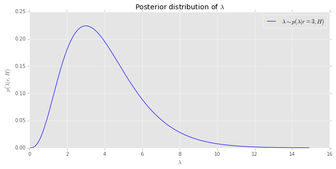

```python
%matplotlib inline
import matplotlib.pyplot as plt
import numpy as np
import math

plt.figure(figsize=(11,5))
lambda1 = np.arange(0,15,0.1)
p = np.exp(-lambda1)*pow(lambda1,3)/math.factorial(3)

plt.plot(lambda1,p, "b",label= "$\lambda \sim p(\lambda|r=3,H)$")
plt.xlabel("$\lambda$")
plt.ylabel(r"$p(\lambda|r,H)$")
plt.title("Posterior distribution of $\lambda$")
plt.legend(loc="best")
plt.style.use("ggplot")
```

### First of all, let's simulate the data pairs **(x,r)**.

$\boldsymbol{x}$ is a random variable ( e.g.the energy of electrons in nuclear Physics ), $\boldsymbol{r}$ is a variable dependent ( e.g.the detected counts in the detector ), for each data pair $(x_b,r_b)$, (b = 1,2,3 ...B), B is the maximum number of outcomes.

$ r_b \sim$ Poisson($ \lambda_b $).

where, Poisson($ \lambda_b $) = p$(r_{b}|\lambda _{b}) = \frac{e ^{-\lambda _{b}} \lambda_{b} ^{r_{b}}} {r_{b}!} $.

### With this in mind, we build up a model, say $\boldsymbol{\lambda} = \theta_{0} + \theta_{1} \boldsymbol{x} $ ,

$\boldsymbol{\lambda}$ = {$\lambda_1, \lambda_2, \lambda_3 \cdots \lambda_B $}, $\boldsymbol{x}$ = {$ x_1, x_2 ,x_3 \cdots x_B $}.

where $\theta_0 $ and $ \theta_1$ are parameters we are interested.

Define the random variable $\boldsymbol{x}$ has value $\boldsymbol{x}$ $\in$(0,20), $ \theta_0 =1 $ , $ \theta_1 = 2 $ . Next, we use the model $\boldsymbol{\lambda} = \theta_{0} + \theta_{1} \boldsymbol{x} $ to generate $\boldsymbol{\lambda}$ , then the corresponding $\boldsymbol{r}$ follows from $\boldsymbol{r}$ = Poisson($\boldsymbol{\lambda}$).

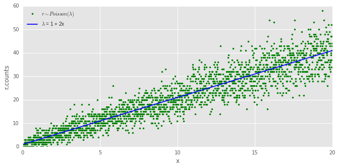

```python
%matplotlib inline
import random
import matplotlib.pyplot as plt
import numpy as np
import math
from  IPython.core.pylabtools import figsize
import scipy.stats as stats
from scipy import optimize
import scipy.optimize as opt

B = 2000  # the total number of outcomes
figsize(11,5)
np.random.seed(1)
theta_true = (1,2)
x_b = np.linspace(0,20,B,endpoint=False)  #the number of x_b is 2000.
lambdaa1 =  theta_true[0]+theta_true[1]*x_b  # this is the model build up.
r_b = np.random.poisson(lambdaa1)  # r_b is the counts generated from  poisson(lambda1)

plt.plot(x_b,r_b,"g.",label="$r\sim Poisson(\lambda) $")
plt.plot(x_b,lambdaa1,"b",label="$\lambda$ = 1 + 2x")
plt.legend(loc="best")
plt.xlabel("x")
plt.ylabel("r,counts")
plt.grid(True)
```

The distance between the green dots ( the simulated data points **r** ) and the blue line is the error.

Now, here comes out a question, **what if we don't know the value of parameters $\theta_0 $ and $ \theta_1$ ?**

For example, after an experiment , we obtain a bunch of data **(x,r)**, we want to describe the relationship between **x and r**. Then we need to evaluate $\boldsymbol{\lambda}$ in order to find the best fitting.

Generally, there are two ways of solving this problem. The fundamental difference between the two methods is how we treat the model parameters $\boldsymbol{\lambda}$ we are interested , in this case, $\boldsymbol{\lambda} \sim \boldsymbol{\theta}$, $\theta_0 $ and $ \theta_1$ are hyperparameters . The traditional frequentist method treat the value of $\boldsymbol{\theta}$ fixed, and derive quantities from random repeated events, the mathematical notation is the conditional distribution :$p(D|\theta,H)$. The other way is Bayesian method, our belief about parameters $\boldsymbol{\theta}$ change according to fixed observed data, mathematical speaking is $p(\theta|D,H)$. In this post I focus on this approach.

### Since we have no idea about the hyperparameters $\theta_0 $ and $ \theta_1$ , the best way to do is to say they are uniform distributed. Also we know the counts are integers, then we can say likelihood function is a poisson pmf, assuming the model is $\lambda=\theta_0 + \theta_1 x$ .

```
Applied interval-transform to theta_0 and added transformed theta_0_interval to model.
Applied interval-transform to theta_1 and added transformed theta_1_interval to model.
 [-----------------100%-----------------] 2000 of 2000 complete in 8.7 sec
theta_0:

  Mean             SD               MC Error         95% HPD interval
  -------------------------------------------------------------------

  0.982            0.102            0.004            [0.779, 1.174]

  Posterior quantiles:
  2.5            25             50             75             97.5
  |--------------|==============|==============|--------------|

  0.790          0.913          0.979          1.053          1.187


theta_1:

  Mean             SD               MC Error         95% HPD interval
  -------------------------------------------------------------------

  1.999            0.014            0.000            [1.972, 2.027]

  Posterior quantiles:
  2.5            25             50             75             97.5
  |--------------|==============|==============|--------------|

  1.969          1.989          1.999          2.008          2.025
```

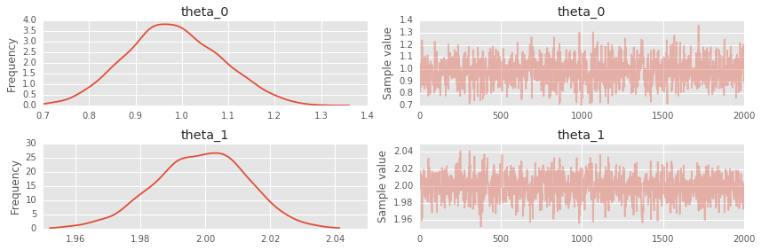

```python
%matplotlib inline
import pymc3 as pm
from  IPython.core.pylabtools import figsize
from pymc3 import Model,Normal,HalfNormal,find_MAP,Poisson,Metropolis,traceplot,sample,NUTS
figsize(11,5)
np.random.seed(1)
with pm.Model() as model1:
    theta_0 = pm.Uniform("theta_0",lower=0,upper=10)
    theta_1 = pm.Uniform("theta_1",lower=0,upper=10)
    lambdaa1 = theta_0 + theta_1*x_b
    Y_obs   = pm.Poisson("Y_obs",mu=lambdaa1,observed=r_b) #we treat observed data(x,r) as fixed value, then combine
                       #p(λ|H) with likelihood function p(r|λ,H),by caculating the product of p(λ|H)*p(r|λ,H) to find MAP.
    start = pm.find_MAP(fmin=optimize.fmin_powell)
    step  = pm.NUTS(scaling=start)
    trace = pm.sample(B ,step,start=start,progressbar=True)
    pm.traceplot(trace)
    pm.summary(trace)
```

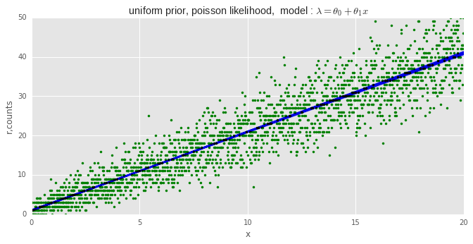

```python
%matplotlib inline
from mpl_toolkits.mplot3d import Axes3D

theta_0_posterior = trace['theta_0']
theta_1_posterior = trace['theta_1']

fig = plt.figure(figsize=(11,5))

x_b = np.linspace(0,20,n, endpoint = False)
lambdaa1 =  theta_true[0]+theta_true[1]*x_b  # this is the model build up.
r_b = np.random.poisson(lambdaa1)  # r_b is the counts generated from  poisson(lambda1)
plt.plot(x_b,r_b, "g.")
for i in range(B):
    lambdaa11 = theta_0_posterior[i]+ theta_1_posterior[i]*x_b # Watch out! The parameters have changed.
    plt.plot(x_b, lambdaa11, 'b', alpha=0.005)

plt.ylim((0,50))
plt.xlim((0,20))
plt.xlabel("x")
plt.ylabel("r,counts")

plt.title(r" uniform prior, poisson likelihood,  model : $ \lambda = \theta_{0}+ \theta_{1} x $")
```

The green dots are the original generated data points(x,r), these blue lines are represented by $\lambda$ = $\theta_0 + \theta_1$ x, where each $\theta_0$ and $\theta_1$ are drawn from posterior estimated value .

Next, let's take a look at the marginal distribution of prior $p( \theta_0, \theta_1 |H )$ and posterior $p(\theta_0 , \theta_1|\boldsymbol{x},\boldsymbol{r}, H )$ respectively.

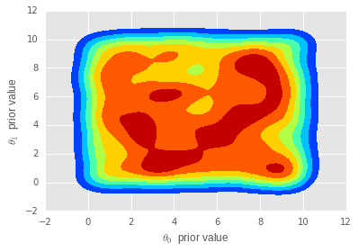

```python
%matplotlib inline
import seaborn as sn

jet = plt.cm.jet
ax = fig.add_subplot(211)
theta_0prior=np.random.uniform(0,10,B)
theta_1prior=np.random.uniform(0,10,B)
sn.kdeplot(theta_0prior,theta_1prior,shade=True,cmap=plt.cm.jet, shade_lowest=False)
plt.xlabel(r'$\theta_0$  prior value')
plt.ylabel(r'$\theta_1$  prior value')
plt.style.use("ggplot")
plt.grid(True)
```

This figure is **the contour prior uniform distribution (0,10)** of parameters $\theta_0 $ and $ \theta_1$ .

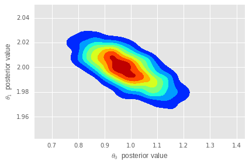

```python
ax = fig.add_subplot(212)
sn.kdeplot(theta_0_posterior ,theta_1_posterior, shade=True, cmap= plt.cm.jet, shade_lowest=False)
plt.xlabel(r"$\theta_0$  posterior value")
plt.ylabel(r"$\theta_1$  posterior value")
plt.style.use("ggplot")
plt.grid(True)
plt.tight_layout()
plt.colorbar()
```

After incorporating our observed data(x,r) , the contour plot of **the posterior distribution** of $\theta_0 $ and $ \theta_1$ shink to a more centered area around**(1.0,2.0)** , which is exactly the true value we defined.

The darker the red color, the higher probability of the values are located in that area. On the contrary, the blue color represents the lowest probability of the assigned value.